# Report for *South Asia* and CO2-emissions between **0** and **50**

## Simple correlations from the lecture’s dataset

With this dataset, one can visualize the few correlations introduced in the [Google Sheets Document](https://docs.google.com/spreadsheets/d/1NZpys5yniDyOuUPxV7JKWkcTP-FUZL1esZSvUitZPd0/edit?usp=sharing). This is done with the package *PerformanceAnalytics* as follows.

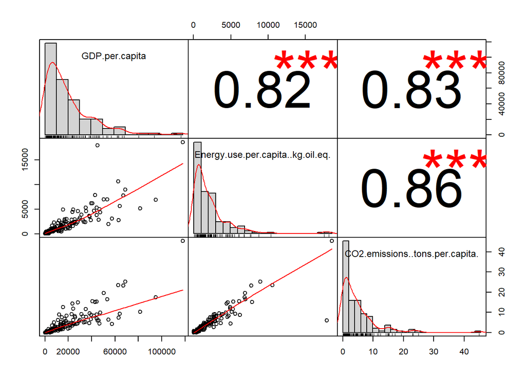

Focusing first on the scatterplots, the graphical matrix could be read as one read for example a multiplication table, that is reading the rows first and then the columns: There, were the row belonging to *Energy Use per Capita* meets the column of *GDP per Capita*, the scatter-plot suggests a rather pronounced correlation between these 2 variables, although the correlation between *Energy Use per Capita* and *CO2 Emissions per Capita* appears to be slightly more significant. Not surprisingly given the well-known fact that fossile fuels still account for about 80 pct. of total energy consumed on the global level, far ahead of the share of renewable energy sources (around 10 pct.) as discussed during the lectures.

The 3 scatterplots can be drawn once more, this time visualizing the income groups each country (point) pertains to:

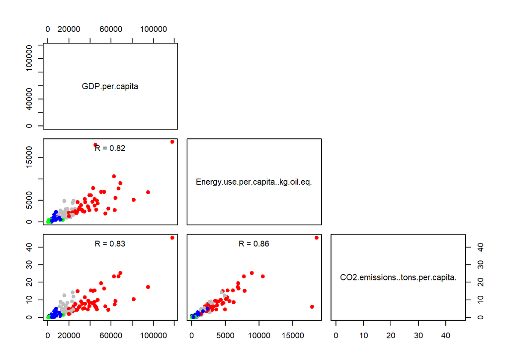

**PS**: The colour conventions are:

- **Red** for *high income* countries
- **Green** for *low income* countries
- **Blue** for *lower middle income* countries
- **Grey** for *upper middle income* countries

## Extended Correlation Structure

In the same fashion, one can expand the correlation matrix to include the remainder of the continuous variables at hand:

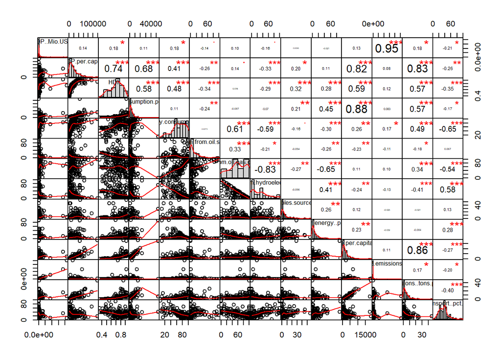

Given the difficulty to distinguish between the details in such a graphical illustration, one can list the strongest correlations among all variables. This have been carried out in the next code chunk. In passing, note that the strongest relationships in the matrix are suggested by the number of red stars (3 means likelier relationships) or the numerical value of the correlation coefficient (stronger correlations where the coefficient is closer to 1 in absolute terms). Any biasing effects from outliers have been ignored.

```
##     Var1
## 155 "GDP..Mio.USD."
## 144 "Electricity.Consumption.per.capita..kWh"
## 179 "Energy.use.per.capita..kg.oil.eq."
## 170 "GDP.per.capita"
## 142 "GDP.per.capita"
## 30  "GDP.per.capita"
## 44  "GDP.per.capita"
## 89  "Fossil.fuel.energy.consumption..pct..of.total."
## 187 "Fossil.fuel.energy.consumption..pct..of.total."
## 133 "Electricity.production.from.oil.gas.coal.sources..pct.of.total."
## 105 "Electricity.production.from.oil.gas.coal.sources..pct.of.total."
##     Var2
## 155 "CO2.emissions..kt."
## 144 "Energy.use.per.capita..kg.oil.eq."
```

[output cut: 21 more lines]

The correlation coefficients are arranged in descending order, and the ones of interest are those that are closest to 1 in absolute values.

Hence, there seems to be further relevant correlations among the variables from the extended dataset. To name a few …

- On the positive side:
  - Total income and total CO2-emissions,
  - Electricity Consumption and Energy Use per capita,
- On the negative side:
  - Electricity production from fossile fuels and from hydroelectric sources
  - Electricity production from fossile fuels and from alternative and nuclear energy

This seems in line with general intuition and corroborates earlier observations.

## Final thoughts

[output not shown]

[output not shown]